[**Imtiaj.**](https://imtiajiqbalmahfuj.github.io/index.html#top)

# Machine Learning-Driven Flash Drought Susceptibility Modeling with XAI Analytics

### Explainable AI (SHAP) and Multi-Source Satellite Feature Engineering for Proactive Climate Risk Intelligence

> 🌍 *Leveraging Earth Engine and leakage-free Machine Learning architectures to isolate the hydro-meteorological and vegetative precursors of rapid-onset flash droughts.* ⚡

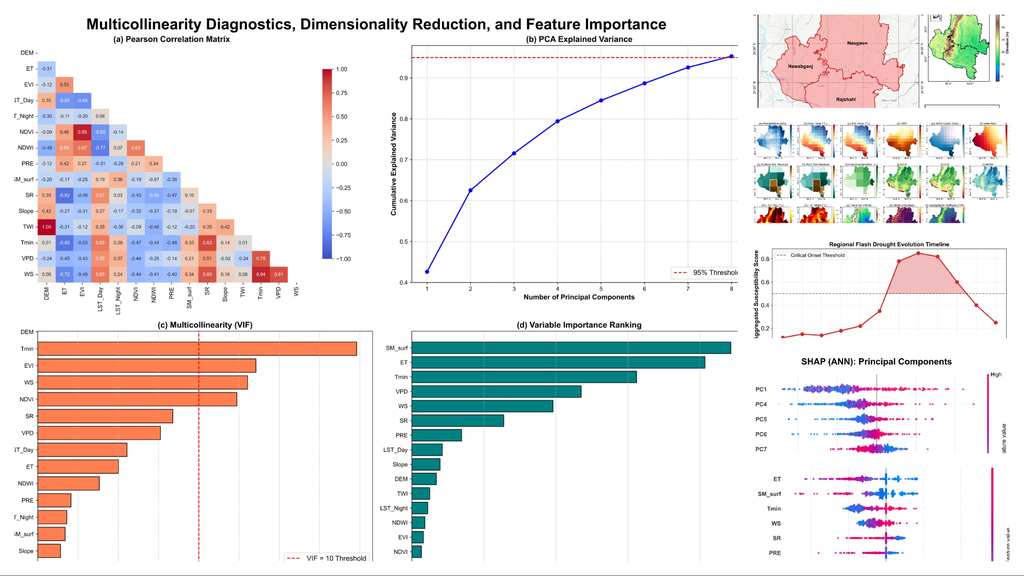

> **Author:** Imtiaj Iqbal Mahfuj

## 📝 Overview

This project explores **spatial patterns**, integrates **remote sensing datasets**, and applies **geospatial Python tools** to visualize and analyze flash drought vulnerabilities. Rapid-onset climatic anomalies known as flash droughts pose an existential threat to seasonal agricultural security due to their sudden onset, which bypasses traditional early warning mechanisms. This research develops a rigorous, end-to-end predictive pipeline targeting the highly vulnerable Barind Tract ROI in northwestern Bangladesh (encompassing Rajshahi, Naogaon, and Chapainawabganj) during the critical pre-monsoon dry season.

The primary objective is to engineer a highly generalized, leakage-free modeling framework that evaluates 15 competitive machine learning, deep learning (1D-CNN), and boosting architectures. By framing the problem through spatial multi-source array extraction via Google Earth Engine (GEE), the system identifies real-time agricultural anomalies based on joint thresholds of maximum temperature ($T_{max} \ge \text{80th percentile}$) and root-zone soil moisture deficits ($\text{SM}_{root} \le \text{20th percentile}$).

This work serves researchers, environmental engineers, regional agricultural planners, and policy-makers by bridging the gap between complex black-box machine learning predictions and human-interpretable climate science. Utilizing cutting-edge eXplainable AI (XAI) diagnostics via SHAP kernel explainers, the system effectively decodes the exact physical factors governing spatial vulnerability, establishing a robust blueprint for data-driven climate resilience.

## 🛠️ Tools & Technologies

## ⚙️ Methodology

[output not shown]

# Codes

## Environment Setup, IEEE Styling, and Earth Engine Initialization

```python
import os
import ee
import geemap
import numpy as np
import pandas as pd
import geopandas as gpd
import matplotlib.pyplot as plt
import matplotlib.patches as mpatches
from matplotlib.ticker import MaxNLocator, FuncFormatter
from shapely.geometry import Point
from matplotlib_scalebar.scalebar import ScaleBar
import warnings

# warnings.filterWarning("ignore")

# Initialize Earth Engine
ee.Authenticate(auth_mode='localhost')
ee.Initialize()

# Create a dedicated directory to save high-resolution IEEE plots
OUTPUT_DIR = "IEEE_Manuscript_Plots"
os.makedirs(OUTPUT_DIR, exist_ok=True)
```

```python
# IEEE Journal Publication Styling (Strict Serif, High DPI)
# Reference: IEEE Author Center Graphics Guidelines
plt.rcParams.update({
    'font.family': 'sans-serif',
    'font.sans-serif': ['Arial', 'Helvetica', 'DejaVu Sans'],
    'text.usetex': False,            # Prevents LaTeX rendering engines from introducing blurry halos
    'mathtext.fontset': 'cm',        # Standard clean math typography block
    'font.size': 13,
    'axes.titlesize': 14,
    'axes.labelsize': 14,
    'xtick.labelsize': 14,
    'ytick.labelsize': 14,
    'legend.fontsize': 12,
    'figure.dpi': 500,               # Maintained high resolution for exports
    'savefig.dpi': 500,
    'savefig.bbox': 'tight'
})

def apply_custom_map_style(ax, reference_gdf, title="", tight=False, is_factor_grid=False):
    """Applies IEEE standard mapping styles, scalebars, and North arrows."""
    if is_factor_grid:
        ax.tick_params(top=True, bottom=True, left=True, right=True,
                       direction='in', labeltop=False, labelbottom=True,
                       labelleft=True, labelright=False, pad=4, labelsize=7)
        ax.xaxis.set_major_locator(MaxNLocator(nbins=3, prune='both'))
        ax.yaxis.set_major_locator(MaxNLocator(nbins=3, prune='both'))
        ax.set_title(title, pad=12, fontweight='bold', fontsize=14)
    else:
        ax.tick_params(top=True, bottom=True, left=True, right=True,
                       direction='in', labeltop=True, labelbottom=True,
                       labelleft=True, labelright=True, pad=5, labelsize=8)
        ax.xaxis.set_major_locator(MaxNLocator(nbins=4, prune='both'))
        ax.yaxis.set_major_locator(MaxNLocator(nbins=4, prune='both'))
        ax.set_title(title, pad=30, fontweight='bold', fontsize=20)

    ax.tick_params(axis='y', labelrotation=90)
    ax.xaxis.set_major_formatter(FuncFormatter(lambda x, _: f"{x:.2f}° E"))
    ax.yaxis.set_major_formatter(FuncFormatter(lambda y, _: f"{y:.2f}° N"))

    # Add Scale Bar and North Arrow Elements
    projected_centroid = reference_gdf.to_crs(epsg=32646).geometry.centroid.to_crs(epsg=4326)
    center_lat = projected_centroid.y.iloc[0]
    deg_points = gpd.GeoSeries([Point(91.0, center_lat), Point(92.0, center_lat)], crs="EPSG:4326").to_crs(epsg=32646)
    meters_per_degree = deg_points.iloc[0].distance(deg_points.iloc[1])

    scalebar = ScaleBar(dx=meters_per_degree, units="m", location="lower right",
                        box_alpha=0.7, color='black', font_properties={'size': 7})
    ax.add_artist(scalebar)

    ax.annotate('N', xy=(0.93, 0.93), xytext=(0.93, 0.87),
                arrowprops=dict(facecolor='black', width=1.0, headwidth=4, shrink=0.05),
                ha='center', va='center', fontweight='bold', fontsize=8, xycoords='axes fraction')

    # Handle Frame Boundaries
    bounds = reference_gdf.total_bounds
    padding = 0.006 if tight else 0.016
    ax.set_xlim(bounds[0] - padding, bounds[2] + padding)
    ax.set_ylim(bounds[1] - padding, bounds[3] + padding)
```

```python
# Define the Barind Tract ROI (Rajshahi, Naogaon, Chapainawabganj)
# Citation: (Islam et al., 2026; Geographic demarcation of extreme hydroclimatic vulnerability)
dataset = ee.FeatureCollection("FAO/GAUL/2015/level2")
barind_tract = dataset.filter(ee.Filter.inList('ADM2_NAME', ['Rajshahi', 'Naogaon', 'Nawabganj']))
roi = barind_tract.geometry()

print("Environment configured and Barind Tract ROI defined.")
```

```
Environment configured and Barind Tract ROI defined.
```

## Study Area Map: Perfect Masking, Centered Title, & Matched Legend

```python
# Study Area Map: Perfect Masking, Centered Title, & Matched Legend

import os
import ee
import geemap
import copy
import numpy as np
import geopandas as gpd
import matplotlib.pyplot as plt
from matplotlib.ticker import MaxNLocator, FuncFormatter
from matplotlib.gridspec import GridSpec
from matplotlib_scalebar.scalebar import ScaleBar
from mpl_toolkits.axes_grid1.inset_locator import inset_axes
from mpl_toolkits.axes_grid1 import make_axes_locatable # Added for perfect legend sizing
import matplotlib.patches as mpatches
import contextily as cx

# 1. Initialize Earth Engine
try:
    ee.Initialize()
except Exception as e:
    ee.Authenticate()
    ee.Initialize()

# 2. Configuration & IEEE Styling
OUTPUT_DIR = "IEEE_Manuscript_Plots"
os.makedirs(OUTPUT_DIR, exist_ok=True)

plt.rcParams.update({
    'font.family': 'sans-serif',
    'font.sans-serif': ['Arial', 'Helvetica', 'DejaVu Sans'],
    'font.size': 12,
    'axes.labelsize': 12,
    'xtick.labelsize': 10,
    'ytick.labelsize': 10,
    'figure.dpi': 500,
    'savefig.dpi': 500,
    'savefig.bbox': 'tight'
})

# 3. Define the Study Area
COUNTRY = 'Bangladesh'
DISTRICTS = ['Rajshahi', 'Naogaon', 'Nawabganj']

print(f"Fetching boundaries for {COUNTRY} and {', '.join(DISTRICTS)}...")

country_ee = ee.FeatureCollection("FAO/GAUL/2015/level0").filter(ee.Filter.eq('ADM0_NAME', COUNTRY))

districts_ee = ee.FeatureCollection("FAO/GAUL/2015/level2") \
    .filter(ee.Filter.eq('ADM0_NAME', COUNTRY)) \
    .filter(ee.Filter.inList('ADM2_NAME', DISTRICTS))

aoi_ee = districts_ee.geometry()

# Convert to GeoDataFrames
country_gdf = geemap.ee_to_gdf(country_ee)
districts_gdf = geemap.ee_to_gdf(districts_ee)
aoi_gdf = gpd.GeoDataFrame(geometry=[districts_gdf.unary_union], crs="EPSG:4326")

bounds = aoi_gdf.buffer(0.12).total_bounds
lon_min, lat_min, lon_max, lat_max = bounds

# 4. Fetch DEM specifically for the AOI
print("Fetching DEM Array with strict binary masking...")
dem = ee.Image("USGS/SRTMGL1_003").rename('elevation')

# CRITICAL FIX: Create a perfect 1/0 mask in Earth Engine to eliminate the blue box
mask_band = ee.Image(1).clip(aoi_ee).unmask(0).rename('ROI_MASK')
combined_dem = dem.addBands(mask_band).unmask(-9999)

dem_arr_raw = geemap.ee_to_numpy(combined_dem, region=aoi_ee, scale=90)
dem_arr = dem_arr_raw.astype(float)

dem_slice = dem_arr[:, :, 0]
mask_slice = dem_arr[:, :, 1]

# Enforce strict NaN transparency on anything outside the exact district lines
dem_slice = np.where(mask_slice == 1, dem_slice, np.nan)
dem_slice[dem_slice < -9000] = np.nan

dem_bounds = aoi_gdf.total_bounds
d_lon_min, d_lat_min, d_lon_max, d_lat_max = dem_bounds

# ==============================================================================
# 5. BUILD THE FIGURE AND TIGHT GRIDSPEC LAYOUT
# ==============================================================================
fig = plt.figure(figsize=(12, 9))

# CRITICAL FIX 2: Exactly center the title on the canvas
fig.suptitle("Study Area Map", fontsize=24, fontweight='bold', x=0.5, y=0.97, ha='center')

# Tighten the left edge to remove massive white space
fig.subplots_adjust(left=0.06, right=0.96, top=0.90, bottom=0.05)

# height_ratios=[2, 1] enforces the 2/3 and 1/3 split. wspace=0.02 pulls the center gap tighter.
gs = GridSpec(2, 2, width_ratios=[2.5, 1.1], height_ratios=[2, 1], wspace=0.02, hspace=0.08)

ax_main = fig.add_subplot(gs[:, 0])
ax_dem = fig.add_subplot(gs[0, 1])
ax_legend = fig.add_subplot(gs[1, 1])

# ---------------------------------------------------------
# PANEL A: MAIN MAP
# ---------------------------------------------------------
ax_main.set_xlim(lon_min, lon_max)
ax_main.set_ylim(lat_min, lat_max)

# Define dynamic variables so the map and legend auto-sync
poly_facecolor = '#FF4444'
poly_edgecolor = '#CC0000'

districts_gdf.plot(ax=ax_main, facecolor=poly_facecolor, alpha=0.35, zorder=2)
districts_gdf.boundary.plot(ax=ax_main, edgecolor=poly_edgecolor, linewidth=1.5, zorder=3)


print("Downloading high-res Esri basemap...")
cx.add_basemap(ax_main, crs="EPSG:4326", source=cx.providers.Esri.WorldTopoMap, alpha=0.85, zorder=1)

for idx, row in districts_gdf.iterrows():
    centroid = row.geometry.centroid
    # Removed the bbox parameter entirely and set color to black
    ax_main.text(centroid.x, centroid.y, row['ADM2_NAME'],
                 fontsize=15, fontweight='bold', color='black', ha='center', va='center', zorder=4)

ax_main.grid(True, linestyle='--', color='black', alpha=0.5, zorder=5)
ax_main.tick_params(top=True, bottom=True, left=True, right=True,
                    labeltop=True, labelbottom=True, labelleft=True, labelright=True,
                    direction='in', length=8, width=1.2, pad=6)
ax_main.tick_params(axis='y', labelrotation=90)
ax_main.xaxis.set_major_formatter(FuncFormatter(lambda x, _: f"{x:.2f}° E"))
ax_main.yaxis.set_major_formatter(FuncFormatter(lambda y, _: f"{y:.2f}° N"))
# Prunes the very first and last tick marks so they stop overhanging the borders
ax_main.xaxis.set_major_locator(MaxNLocator(nbins=5, prune='both'))
ax_main.yaxis.set_major_locator(MaxNLocator(nbins=5, prune='both'))

for spine in ax_main.spines.values():
    spine.set_linewidth(1.5)
    spine.set_zorder(6)

ax_main.annotate('N', xy=(0.95, 0.95), xytext=(0.95, 0.86),
                 arrowprops=dict(facecolor='black', width=3.0, headwidth=12, shrink=0.05),
                 ha='center', va='center', fontweight='bold', fontsize=18,
                 xycoords='axes fraction', textcoords='axes fraction', zorder=6)

center_lat = (lat_min + lat_max) / 2
meters_per_degree = 111320 * np.cos(np.radians(center_lat))
scalebar = ScaleBar(dx=meters_per_degree, units="m", location="lower left",
                    box_alpha=0.85, color='black', font_properties={'size': 12, 'weight': 'bold'})
scalebar.set_zorder(6)
ax_main.add_artist(scalebar)

# ---------------------------------------------------------
# PANEL B: DEM MAP (Top Right)
# ---------------------------------------------------------
ax_dem.set_facecolor('white')

cmap_dem = copy.copy(plt.get_cmap('terrain'))
cmap_dem.set_bad(color='white', alpha=0)

im_dem = ax_dem.imshow(dem_slice, cmap=cmap_dem, extent=[d_lon_min, d_lon_max, d_lat_min, d_lat_max])
districts_gdf.boundary.plot(ax=ax_dem, color='black', linewidth=1.2)
ax_dem.set_title("Elevation Profile", fontweight='bold', fontsize=14, pad=10)

# CRITICAL FIX: Forces the box to grow taller without stretching the map.
y_pad = (d_lat_max - d_lat_min) * 0.15
ax_dem.set_ylim(d_lat_min - (y_pad * 0.2), d_lat_max + y_pad) # Extra padding at the top for the Inset Map!

# CRITICAL FIX: Sub-divide ax_dem to attach the colorbar inside the same GridSpec cell
# This guarantees ax_legend perfectly matches their combined width below.
divider = make_axes_locatable(ax_dem)
cax = divider.append_axes("right", size="5%", pad=0.15)
cbar = plt.colorbar(im_dem, cax=cax)
cbar.set_label('Elevation (m)', weight='bold', fontsize=11)
cbar.ax.tick_params(labelsize=9)

ax_dem.tick_params(direction='in', labelsize=9)
ax_dem.tick_params(axis='y', labelrotation=90)
ax_dem.xaxis.set_major_formatter(FuncFormatter(lambda x, _: f"{x:.1f}°"))
ax_dem.yaxis.set_major_formatter(FuncFormatter(lambda y, _: f"{y:.1f}°"))
ax_dem.xaxis.set_major_locator(MaxNLocator(nbins=3, prune='both'))
ax_dem.yaxis.set_major_locator(MaxNLocator(nbins=3, prune='both'))

for spine in ax_dem.spines.values():
    spine.set_linewidth(1.2)

# Float the inset map in the empty white space at the top-left of the DEM panel
inset_ax = inset_axes(ax_dem, width="20%", height="20%", loc='upper left', borderpad=0.5)
country_gdf.plot(ax=inset_ax, color='lightgray', edgecolor='black', linewidth=0.5)
aoi_gdf.plot(ax=inset_ax, color='red', edgecolor='darkred', linewidth=1)

inset_ax.set_xticks([])
inset_ax.set_yticks([])
for spine in inset_ax.spines.values():
    spine.set_linewidth(1)
# inset_ax.set_title("Location", fontsize=9, weight='bold', pad=4)

# PANEL C: PERFECTLY MATCHED LEGEND (Bottom Right)
# ---------------------------------------------------------
# Turn ON the axis spines to serve as the legend's outer box, matching DEM width
ax_legend.axis('on')
ax_legend.set_xticks([])
ax_legend.set_yticks([])
ax_legend.set_facecolor('#FAFAFA')

for spine in ax_legend.spines.values():
    spine.set_linewidth(1.5)
    spine.set_edgecolor('black')

# Legend now dynamically pulls the exact colors from the variables above
legend_elements = [
    mpatches.Patch(facecolor=poly_facecolor, alpha=0.4, edgecolor=poly_edgecolor, linewidth=2, label='Study Area Extent'),
    mlines.Line2D([0], [0], color=poly_edgecolor, lw=1.5, label='District Boundary'),
    mpatches.Patch(facecolor='#E6E1D7', edgecolor='none', label='Esri Topo Basemap')
]

leg = ax_legend.legend(handles=legend_elements, loc='upper center', fontsize=14,
                       title="Legend", title_fontproperties={'weight':'bold', 'size':18},
                       frameon=False, labelspacing=1.8, handlelength=2.5)
# ==============================================================================
# Final Output
# ==============================================================================
file_path = os.path.join(OUTPUT_DIR, 'Study_Area_Map_Final_IEEE.png')
plt.savefig(file_path)
print(f"\nMap successfully generated and saved to: {file_path}")
plt.show()
```

Fetching boundaries for Bangladesh and Rajshahi, Naogaon, Nawabganj... Fetching DEM Array with strict binary masking... Downloading high-res Esri basemap...

[figure not shown]